# Fast Slam

slam

Published

October 30, 2023

```julia
using LinearAlgebra, StaticArrays, LogExpFunctions, Distributions, ArraysOfArrays, FillArrays, Plots
```

This notebook looks at a technique for simultaneous localization (finding the position of a robot) and mapping (finding the positions of any obstacles), abbreviated as SLAM. In this model, the probability distribution for the robot’s trajectory $x_{1:t}$ is represented with a set of weighted particles. Let the weight for particle $i$ be denoted $w^i$, and let $W$ denote the sum of all the weights. Each particle also keeps track of the conditional distribution of obstacle locations $m$ given $x_1, \dotsc x_t$. Even though each particle $i$ should be thought of as describing a full potential trajectory $x_1^i, \dotsc x_t^i$, we will only need to store the position at the most recent time $x_t^i$.

```julia
const Dist = Tuple{SVector{2, Float64}, SMatrix{2,2, Float64}}
```

```
Tuple{SVector{2, Float64}, SMatrix{2, 2, Float64}}
```

```julia
sample(d::Dist) = rand(Distributions.MvNormal(d[1], d[2]))
```

```
sample (generic function with 1 method)
```

```julia
struct Particle
    weight::Float64 # stored in log scale
    x::SVector{2, Float64}
    m::Vector{Dist}
end
```

```julia
const k = 6
```

```
6
```

```julia
function init_particles(n)
    d = (zeros(SVector{2}), SMatrix{2,2}(10.0I))
    p = Particle(0.0, zeros(SVector{2}), fill(d, k))
    fill(p, n)
end
```

```
init_particles (generic function with 1 method)
```

```julia
const n = 100
```

```
100
```

```julia
particles = init_particles(n)
```

[output not shown]

The particles $x^i$ at time $t$ will always be samples from a *proposal distribution* $q_t(x^i)$. The weights $w^i$ will be *importance ratios* of the form $C \pi_t(x^i)/q_t(x^i)$, where $\pi_t(x^i)$ is our *target distribution* and $C$ is a constant. Given these particles, we can approximate $E_{X_t \sim \pi_t} f(X_t)$ for any function $f$ by computing

$$\frac{1}{W}\sum_{i=1}^n w^i f(x_t^i) \approx E_{x_t^i \sim q} \frac{\pi(x_t^i)f(x_t^i)}{q(x_t^i)}=\int \pi(x_t^i) dx_t^i = E_{x_t^i \sim \pi} f(x_t^i)$$

In our case, the target distribution $\pi_{t+1}(x^i)$ at time $t+1$ will be the conditional distribution $p(x^i_{1:t+1} | z_{1:t+1})$, and the proposal distribution $q_{t+1}(x^i) = \pi_t(x^i_{1:t})p(x_{t+1} | x_t, z_{1:t+1})$. By Bayes’ rule

$$\pi_{t+1}(x^i) \propto \pi_t(x^i) p(x_{t+1} | x_t) p(z_{t+1} | x_{t+1}, z_{1:t})$$

Similarly,

$$\begin{align*}
q_{t+1}(x^i) &\propto \frac{\pi_t(x^i) p(x_{t+1}, z_{t+1} | x_t, z_{1:t})}{p(z_{t+1} | x_t)}
&= \frac{\pi_t(x^i) p(x_{t+1} | x_t) p(z_{t+1} | x_{t+1}, z_{1:t})}{p(z_{t+1} | x_t, z_{1:t})}
\end{align*}$$

This means the ratio simplifies to $p(z_{t+1} | x_t, z_{1:t})$.

At each step $t$ in time, our algorithm will do the following: 1. Resample the particles in proportion to their importance weights. This effectively turns our samples from $q_t$ into samples from $\pi_t$. 2. Extend each particle, turning the samples from $\pi_t$ into samples from $q_{t+1}$. This requires sampling from $p(x_{t+1}^i | x_t^i, z_{1:t})$, computing the importance weight $p(z_{t+1} | x_T, z_{1:t})$, and updating the associated distribution $p(m | x_{1:t}, z_{1:t})$.

At $t=0$, the proposal and target distributions are the same so we don’t need to resample.

# Resampling

To lower the variance of this approach, we can use stratified sampling. Instead of letting each $u_i$ come from the full interval $[0,W]$, we can restrict each to a separate interval of size $W/n$.

An even lower variance approach is to sample a single uniform number in $[0,W]$ and shift it to each of the stratified intervals. This is called *systematic resampling*.

# Proposing

We will assume a simple dynamics model where $p(x_{t+1} | x_t) = \mathcal{N}(x_t + \delta, \Sigma_A)$. For the likelihood, we observe noisy distances to obstacles, so that an observation at time $t$ is distributed $p(z_t | x_t, m) = \mathcal{N}(m - x_t, \Sigma_B)$.

To find the posterior $p(x_{t+1} | x_t, z_{t+1})$, it will be easier to work with the general case where $A \sim \mathcal{N}(\mu_A, \Sigma_A)$, $B \sim \mathcal{N}(\mu_B, \Sigma_B)$, and $Z \sim \mathcal{N}(B - A, \Sigma_Z)$. Marginalizing out $B$ from the definition of $Z$ gives $Z \sim \mathcal{N}(\mu_B - A, \Sigma_B + \Sigma_Z)$. Let $\Sigma_B + \Sigma_Z = \Sigma_{BZ}$ and $A \circ B \coloneqq \text{Trace}(A^TB)$. By Bayes’ rule:

$$\begin{align*}
\log p(A | Z) &= \log p(A) + \log p(Z | A) + c
&= -\frac{1}{2}(A - \mu_A)^T \Sigma_A^{-1} (A - \mu_A) -\frac{1}{2}(Z - \mu_B + A)^T (\Sigma_{BZ})^{-1} (Z - \mu_B + A) +c
&= -\frac{1}{2} AA^T \circ \Sigma_A^{-1} + A^T \Sigma_A^{-1} \mu_A
-\frac{1}{2} AA^T \circ \Sigma_{BZ}^{-1} + A^T \Sigma_{BZ}^{-1} (\mu_B - Z)
&= -\frac{1}{2} AA^T \circ (\Sigma_A^{-1} + \Sigma_{BZ}^{-1}) + A^T (\Sigma_A^{-1} \mu_A + \Sigma_{BZ}^{-1} (\mu_B - Z))
\end{align*}$$

This shows that the posterior is Gaussian with natural parameters $(\Sigma_A^{-1} \mu_A + \Sigma_{BZ}^{-1} (\mu_B - Z),\, \Sigma_A^{-1} + \Sigma_{BZ}^{-1})$.

For FastSLAM, $\mu_A = x_t + \delta$, so $p(x_{t+1} | x_t, z_{t+1})$ has natural parameters

$$(\Sigma_A^{-1} (x_t + \delta) + (\Sigma_B + \Sigma_Z)^{-1} (\mu_B - z_{t+1}),\, \Sigma_A^{-1} + (\Sigma_B + \Sigma_Z)^{-1})$$

Similarly, to update the obstacle distribution upon seeing $x_{t+1}$ and $z_{t+1}$:
$$\begin{align*}
\log p(M | x_{1:t+1}, z_{1:t+1}) &= -\frac{1}{2} MM^T \circ (\Sigma_B^{-1} + \Sigma_Z^{-1}) + M^T (\Sigma_B^{-1} \mu_B + \Sigma_{Z}^{-1} (Z - x_{t+1})) + c
\end{align*}$$

For the importance weight, note that $p(z_{t+1} | X_t, z_{1:t}) = \mathcal{N}(\mu_B - (x_t + \delta), \Sigma_B + \Sigma_Z)$.

```julia
begin
ΣA = Eye(2,2)
ΛA = inv(ΣA)
ΣZ =  (1/6) * Eye(2,2)
ΛZ = inv(ΣZ)
δ = SVector(2.,2.)
end
```

```
2-element SVector{2, Float64} with indices SOneTo(2):
 2.0
 2.0
```

```julia
post_msg_m(x, z) = (ΛZ \ (z - x), ΛZ)
```

```
post_msg_m (generic function with 1 method)
```

```julia
function stdform((mu, var))
    (var \ mu, inv(var))
end
```

```
stdform (generic function with 1 method)
```

```julia
function meanform((prec_mu, prec))
    (prec \ prec_mu, inv(prec))
end
```

```
meanform (generic function with 1 method)
```

# Fake Data

Here we generate the unknown, true trajectory that the robot takes by following our dynamics model.

We’ll also set up the true but unknown obstacle locations.

```julia
true_ms = 50 * randn(2, k)
```

```
2×6 Matrix{Float64}:
 -81.0076  -51.081   -52.5936    0.785968  -94.2813  -8.10996
  37.3785   36.3637   32.2559  119.206     -23.4696  14.3096
```

The displacement observations the robot sees along its trajectory look like this: To show the direction of time, lines will get fainter with time.

# Simulating the Algorithm

```julia
Base.:+(a::Tuple, b::Tuple) = a .+ b
```

```julia
function resample(w::Vector{Float64})
    u = rand()
    ui = [(u + i-1) / length(w) for i in 1:length(w)]
    bins = cumsum(w)
    [searchsortedfirst(bins, i) for i in ui]
end
```

```
resample (generic function with 1 method)
```

```julia
function post_msg_x(m, z)
    ΣBZ = m[2] + ΣZ
    (ΣBZ \ (m[1] - z), inv(ΣBZ))
end
```

```
post_msg_x (generic function with 1 method)
```

```julia
function importance(m, z, xmean)
    logpdf(Distributions.MvNormal(m[1] - xmean, m[2] + ΣZ), z)
end
```

```
importance (generic function with 1 method)
```

```julia
function propose(p, z)
    post_x_msgs = sum(post_msg_x.(p.m, z))
    xmean = (p.x + δ)
    prior_x_msg = (ΛA * xmean, ΛA)
    xpost = meanform(prior_x_msg .+ post_x_msgs)
    new_x = sample(xpost)
    w = sum(importance.(p.m, z, Ref(xmean)))
    post_m_msgs = post_msg_m.(Ref(new_x), z)
    mpost = meanform.(stdform.(p.m) .+ post_m_msgs)
    Particle(w, new_x, mpost)
end
```

```
propose (generic function with 1 method)
```

```julia
function step(particles::Vector{Particle}, z)
    new_particles = propose.(particles, Ref(z))
    ix = resample(softmax([p.weight for p in new_particles]))
    resampled = new_particles[ix]
    Particle[Particle(0.0, p.x, p.m) for p in resampled]
end
```

```
step (generic function with 1 method)
```

```julia
begin
RΣA = sqrt(ΣA)
true_xs = cumsum(δ .+ RΣA * randn(2, 100), dims=2)
end
```

```
2×100 Matrix{Float64}:
 0.839125  5.15476  6.55827  8.62025  …  175.97   176.38   177.393  181.344
 2.35808   3.41737  4.78382  7.49468     175.738  176.766  179.358  179.892
```

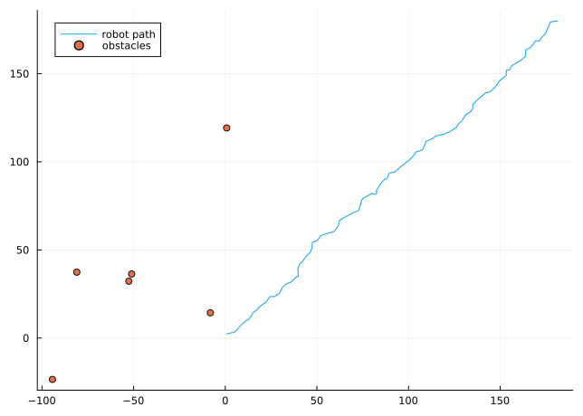

```julia
begin
plot(true_xs[1, :], true_xs[2, :], label="robot path")
scatter!(true_ms[1,:], true_ms[2,:], label="obstacles")
end
```

```julia
begin
RΣZ = sqrt(ΣZ)
true_zs = [(true_ms .- x) + RΣZ * randn(2, k) for x in nestedview(true_xs)]
z = flatview(ArrayOfSimilarArrays(true_zs));
end
```

```
2×6×100 Array{Float64, 3}:
[:, :, 1] =
 -81.532   -51.5233  -53.2692   -0.23741  -95.0439  -7.96016
  35.3408   33.4731   29.7313  117.192    -26.0987  11.9712

[:, :, 2] =
 -86.3235  -56.5942  -57.99     -3.92595  -99.3508  -12.8393
  34.6312   33.0615   29.1957  115.737    -26.7509   10.6348

[:, :, 3] =
 -87.6763  -57.2502  -60.4088   -5.82346  -100.192   -14.1254
  32.2591   31.0896   27.7088  113.71      -28.0589    9.06398

;;; …

[:, :, 98] =
 -258.207  -227.634  -229.429  -175.105   -270.654  -184.669
 -139.723  -140.93   -144.794   -57.5685  -199.917  -162.2

[:, :, 99] =
 -258.67   -229.003  -229.819  -175.965   -271.725  -186.265
 -142.402  -142.704  -147.416   -59.9887  -202.729  -165.072

[:, :, 100] =
 -262.267  -233.015  -233.913  -181.037   -275.374  -190.022
 -142.777  -143.703  -148.27    -60.1598  -203.299  -165.256
```

```julia
timealpha = reverse(0.1 .+ ((1:size(z, 3))./size(z, 3)))
```

```
1.1:-0.01:0.11
```

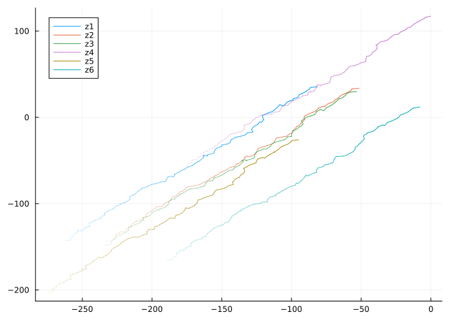

```julia
begin
plt = plot(z[1,1,:], z[2,1,:], label="z1", alpha=timealpha)
for i in 2:k
    plot!(z[1,i,:], z[2,i,:], label="z$i", alpha=timealpha)
end
plt
end
```

```julia
sz = map(SVector{2}, eachslice(z; dims=(3,2)))
```

```
100×6 Matrix{SVector{2, Float64}}:
 [-81.532, 35.3408]    [-51.5233, 33.4731]   …  [-7.96016, 11.9712]
 [-86.3235, 34.6312]   [-56.5942, 33.0615]      [-12.8393, 10.6348]
 [-87.6763, 32.2591]   [-57.2502, 31.0896]      [-14.1254, 9.06398]
 [-89.7375, 29.8168]   [-60.2643, 28.5133]      [-16.4232, 6.27544]
 [-92.5858, 27.3966]   [-62.282, 26.973]        [-19.7571, 3.87832]
 [-94.3631, 26.4263]   [-64.2104, 25.6818]   …  [-21.6505, 3.0456]
 [-95.3876, 23.298]    [-66.7988, 21.9366]      [-23.2036, -0.257843]
 [-98.881, 21.2832]    [-68.7876, 20.1835]      [-24.8147, -1.66672]
 [-98.9132, 19.8718]   [-69.1538, 18.9949]      [-26.462, -2.99735]
 [-101.315, 18.8812]   [-70.6962, 17.3792]      [-28.6426, -4.57781]
 ⋮                                           ⋱  ⋮
 [-250.404, -131.649]  [-220.292, -132.862]     [-177.841, -154.376]
 [-253.277, -131.144]  [-222.942, -132.502]     [-179.607, -154.065]
 [-253.286, -132.041]  [-223.28, -133.938]      [-180.57, -156.488]
 [-254.372, -134.714]  [-225.966, -135.771]     [-182.115, -156.808]
 [-255.751, -135.312]  [-225.695, -136.912]  …  [-182.642, -158.243]
 [-256.865, -138.46]   [-226.085, -139.406]     [-182.666, -160.965]
 [-258.207, -139.723]  [-227.634, -140.93]      [-184.669, -162.2]
 [-258.67, -142.402]   [-229.003, -142.704]     [-186.265, -165.072]
 [-262.267, -142.777]  [-233.015, -143.703]     [-190.022, -165.256]
```

```julia
steps = accumulate(step, eachslice(sz;dims=1); init=particles)
```

[output not shown]

```julia
predicted = SVector{2, Float64}[mean(p-> p.x, s) for s in steps]
```

```
100-element Vector{SVector{2, Float64}}:
 [19.07925008462851, -11.355204348198471]
 [49.28275830446977, -30.307079040350185]
 [51.72716272580613, -29.532508928023354]
 [53.80649579470719, -26.97839162048047]
 [56.369545512019414, -24.73157089497745]
 [58.293274178434324, -23.590308729206527]
 [60.12747706208187, -20.356333809236315]
 [62.324174101435126, -18.29484180762276]
 [62.94681213603732, -17.164265154844426]
 [64.83114263436674, -15.863916269588014]
 ⋮
 [209.93324793778785, 129.93559847476192]
 [212.18444292031216, 129.84167522974928]
 [213.00368746968482, 131.49800787480487]
 [214.30172632694396, 133.06954980462214]
 [214.98489884212927, 134.04035511925161]
 [216.10612184182727, 136.8891699619026]
 [216.6271403671927, 137.83356805431097]
 [217.672155581921, 140.37565441121018]
 [221.59896097004525, 140.93799431444967]
```

```julia
flat_pred = flatview(ArrayOfSimilarArrays(predicted))
```

```
2×100 Matrix{Float64}:
  19.0793   49.2828   51.7272  …  216.106  216.627  217.672  221.599
 -11.3552  -30.3071  -29.5325     136.889  137.834  140.376  140.938
```

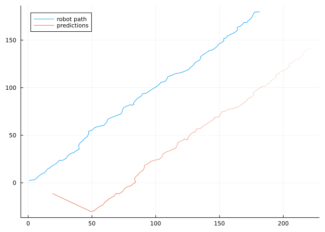

```julia
begin
plot(true_xs[1, :], true_xs[2, :], label="robot path")
plot!(flat_pred[1,:], flat_pred[2,:], label="predictions", alpha=timealpha)
end
```